# Homework 6

December 13, 2023

**Due December 11 prior to 11:59 PM.**

**You may discuss the homework problems and computing issues with other students in the class and submit questions to the Canvas discussion board. However, you must write up your homework solution on your own. In particular, do not share your R files with other students. Please list the students you worked with below.**

Students worked with: XXXXX

Lectures: Module 6

Objectives:

1. Overfitting
2. PCA and PCA regression
3. Lasso
4. Elastic Net

We will use a dataset, MCI_MRI.RData, related to the Alzheimer’s Disease Neuroimaging Initiative data used in HW5 (http://adni.loni.usc.edu/tadpole-challenge-dataset-available/). Parts of the data have been simulated in order to allow data sharing for educational purposes. Qualitatively, the results you discover in this educational dataset are likely to be the same as in the unaltered dataset.

In HW5, we examined hippocampal volume. Here, we will examine hundreds of brain morphometry features, including cortical thickness in different regions of the cortex, standard deviation of cortical thickness in these regions, surface area, and volume.

y: Diagnosis. 0 = cognitively normal; 1 = mild cognitive impairment.

x: MRI features.

labels: categories of variables that will be useful for data exploration.

“Volume (Not Cortex)” is assigned to all structures that are not part of the cerebral cortex, which includes the subcortical gray matter structures such as the hippocampus, as well as the ventricles, which are cavities filled with cerebral spinal fluid that do not contain brain tissue.

“Surface Area” is the estimated surface area for cortical regions, where the regions are defined using a brain parcellation.

“Average cortical thickness” is the thickness of the cortical region averaged across all locations (vertices) that fall in that region.

“SD Cortical Thickness” is the standard deviation of the cortical thickness across all locations (vertices) that fall in that region.

“Cortical Volume” is the estimated volume of gray matter for cortical regions.

The data have been standardized to have unit variance. **Remember that this is important in PCA and penalized regression.** Be careful when working with your own data.

```r
load("MCI_MRI.RData")
```

# 1 Overfitting.

1.1. Fit a model predicting diagnosis using all variables in x. (To save space, do not print the output of summary.) Hint: make $\texttt{x}$ a matrix. Does the fit produce any warnings?

```r
x <- as.matrix(x)
model0 = glm(y~x,family=binomial)
```

```
## Warning: glm.fit: algorithm did not converge
```

```
## Warning: glm.fit: fitted probabilities numerically 0 or 1 occurred
```

1.2 Why are the fitted probabilities numerically 0 or numerically 1?

Mathematically, the algorithm did not converge, and the estimated coefficients $\hat{\beta}$ are Inf or -Inf. Then, $\hat{\mu} = \hat{\beta} x$ is -Inf or Inf, and the estimated probability $= 1/(1+exp(-\hat{\mu}))$ is 0 when $\hat{\mu}$ is -Inf and 1 when $\hat{\mu}$ is Inf. This is because we used lots of variables ($p$ = 328) to fit the outcomes of a relatively small number of observations ($n$ = 350), and there are linear combinations of these variables that can perfectly separate the two groups (cognitively normal vs. mild cognitive impairment).

# 2 PCA.

2.1. Conduct a PCA of x. Create a screeplot of all eigenvalues.

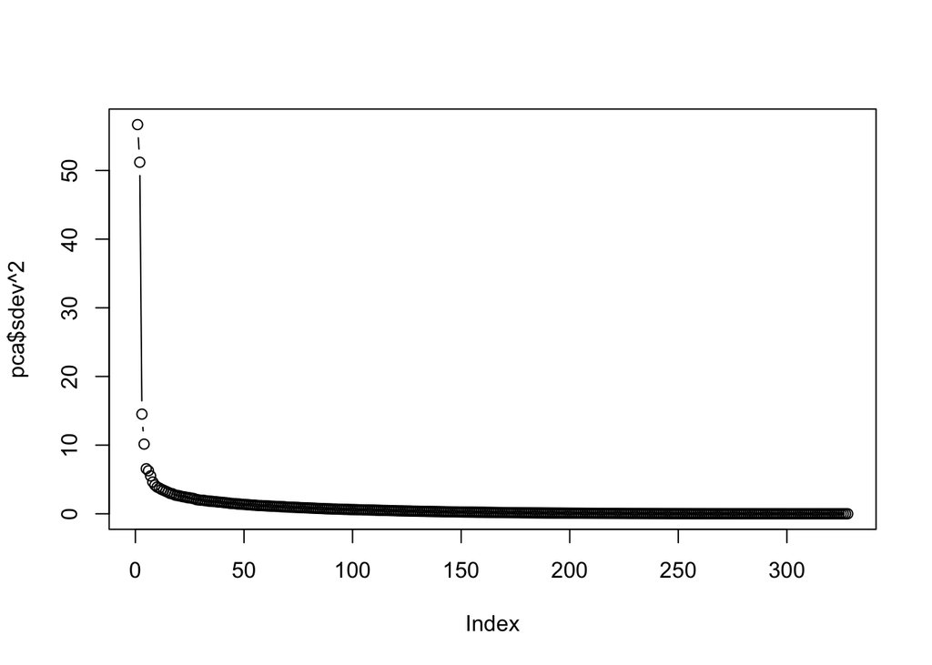

```r
pca = prcomp(x=x, center = TRUE, scale. = F)
plot(pca$sdev^2,type='b')
```

2.2. Create a screeplot of the first 20 eigenvalues only.

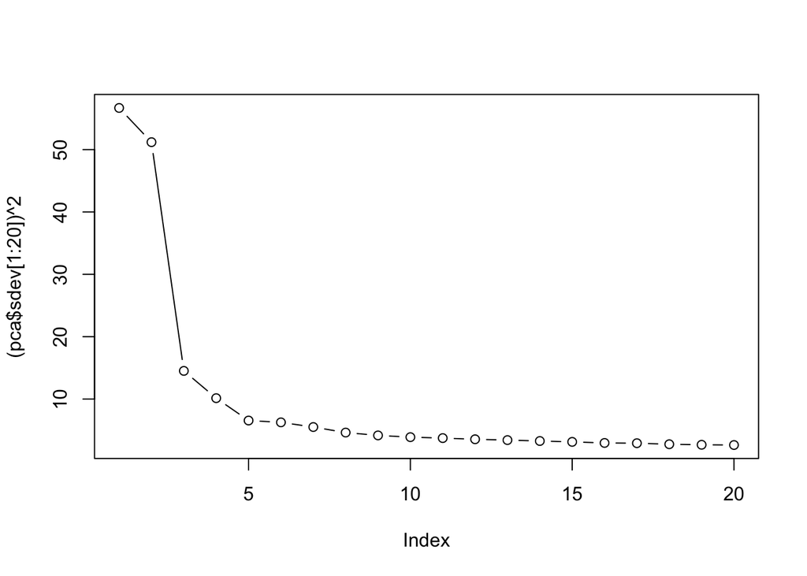

```r
plot((pca$sdev[1:20])^2,type='b') # only show first 20 components
```

2.3. Using the plot of the first 20 eigenvalues, where does the “elbow” occur? How much variance is captured by the components prior to the elbow?

There appears to be an elbow around PC5. The first four components capture approximately 40% of the variance.

```r
(cumsum(pca$sdev^2)/sum(pca$sdev^2))[4]
```

```
## [1] 0.4040938
```

2.4. How many components are required to maintain 90% of the variance?

98 components are required to capture 90% of the variance.

```r
which( cumsum(pca$sdev^2)/sum(pca$sdev^2) >= 0.9)[1]
```

```
## [1] 98
```

2.5. Create a scatter plot of the loadings of PC1 and PC2 with the points colored by `labels`. What patterns do you observe? Which labels tend to cluster?

Yes, there does appear to be clustering by labels.

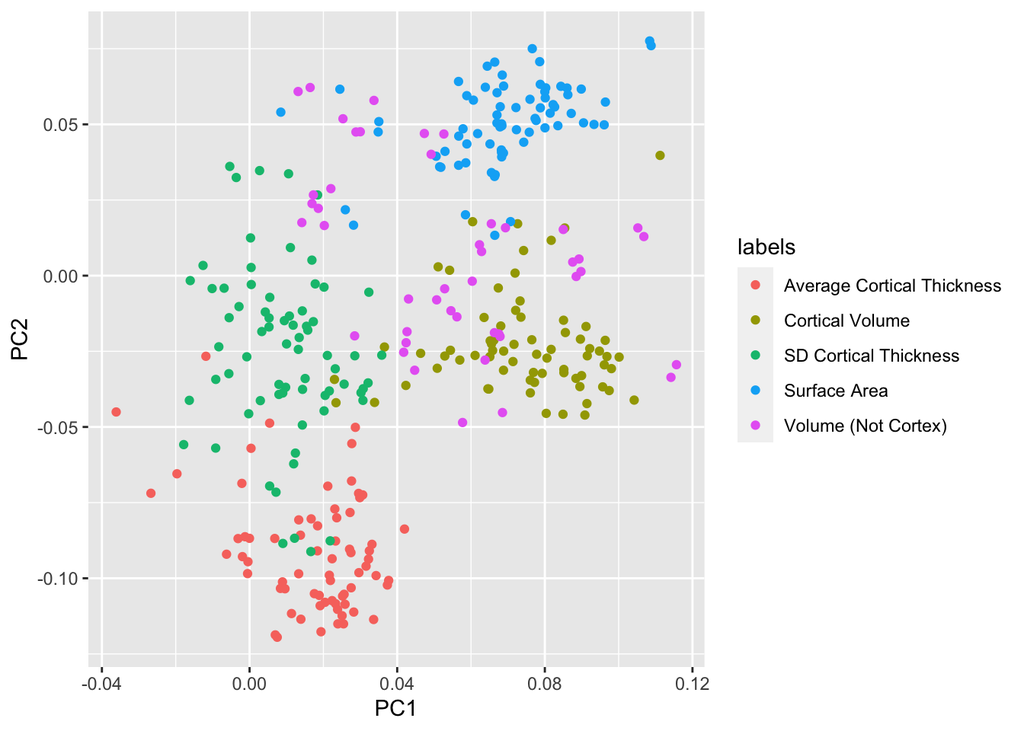

```r
library(ggplot2)
loadings <- data.frame(pca$rotation)
loadings$labels <- labels
ggplot(loadings,aes(x=PC1,y=PC2))+geom_point(aes(color=labels))
```

2.6. Now perform PCA regression using the principal component scores from above and $\texttt{glm}$. You will need to decide on the number of components to include. Print the results from $\texttt{summary()}$.

```r
temp.data = data.frame(y,pca$x)
fit <- glm(y~PC1+PC2+PC3+PC4,data=temp.data,family="binomial")
summary(fit)
```

```
##
## Call:
## glm(formula = y ~ PC1 + PC2 + PC3 + PC4, family = "binomial",
##     data = temp.data)
##
## Deviance Residuals:
##    Min      1Q  Median      3Q     Max
## -2.008  -1.132   0.597   0.961   1.800
##
## Coefficients:
##              Estimate Std. Error z value Pr(>|z|)
## (Intercept)  0.568373   0.121852   4.664 3.09e-06 ***
## PC1          0.003898   0.015664   0.249   0.8035
## PC2          0.093818   0.019153   4.898 9.67e-07 ***
## PC3          0.069652   0.031534   2.209   0.0272 *
## PC4         -0.175074   0.041134  -4.256 2.08e-05 ***
## ---
## Signif. codes:  0 '***' 0.001 '**' 0.01 '*' 0.05 '.' 0.1 ' ' 1
##
## (Dispersion parameter for binomial family taken to be 1)
##
##     Null deviance: 466.75  on 349  degrees of freedom
## Residual deviance: 417.50  on 345  degrees of freedom
## AIC: 427.5
##
## Number of Fisher Scoring iterations: 4
```

2.7. For the most significant component, create a plot of the loadings versus index number and color by the labels. Note the sign of the loadings is not identifiable. For interpretability, multiply all loadings by -1 if the largest loading in magnitude is negative. What patterns do you notice?

The most significant component is PC2. The loadings for all surface area variables are all negative.

```r
loadings$index <- 1:nrow(loadings)
max(loadings$PC2); min(loadings$PC2) # largest loading negative
```

```
## [1] 0.07756113
```

```
## [1] -0.1194834
```

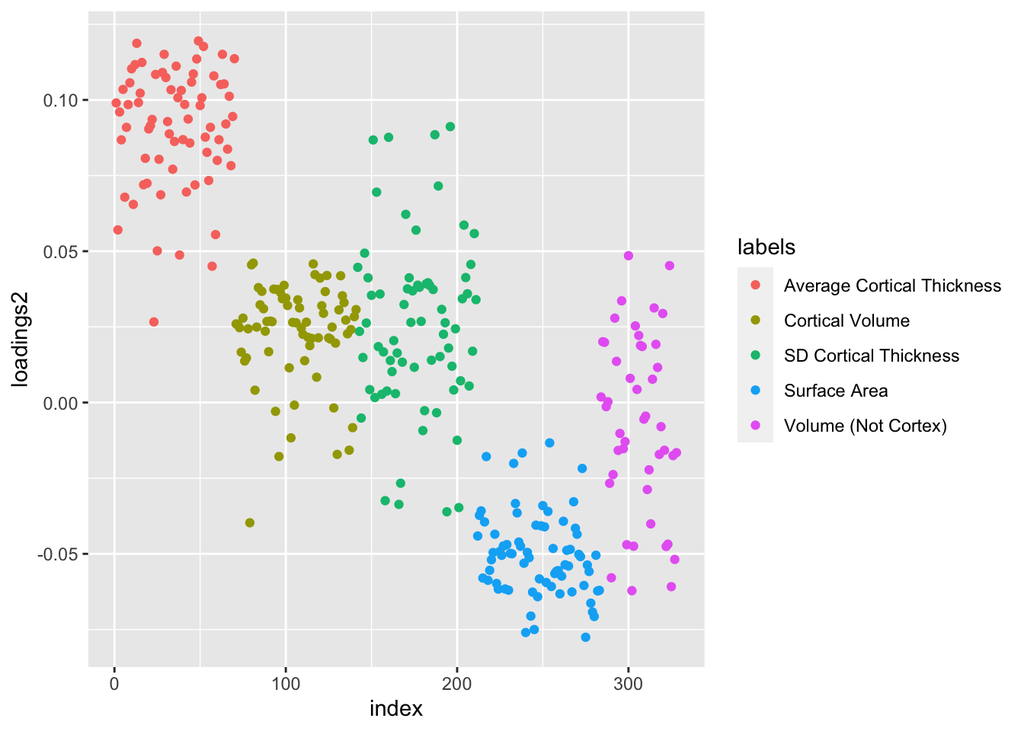

```r
loadings$loadings2 = -1*loadings$PC2
ggplot(loadings,aes(x=index,y=loadings2))+geom_point(aes(col=labels))
```

2.8. What are the VIFs?

```r
library(car)
car::vif(fit)
```

```
##      PC1      PC2      PC3      PC4
## 1.000972 1.038222 1.012292 1.046362
```

```r
fit.lm <- lm(y~PC1+PC2+PC3+PC4,data=temp.data)
vif(fit.lm)
```

```
## PC1 PC2 PC3 PC4
##   1   1   1   1
```

The VIFs are approximately 1 since the predictors are orthogonal. They are exactly equal to 1 in the `lm()`, but for some reason, they are not exactly equal to one in the `glm()`.

# 3 Lasso.

3.1. Fit the penalized glm with all predictors using the lasso with $\texttt{glmnet}$, and create a plot of the coefficient paths using $\texttt{plot()}$. Hint: make $\texttt{x}$ a matrix. What does this plot represent? What is the x axis and y axis? What are the numbers at the top of the figure?

```r
library(glmnet)
```

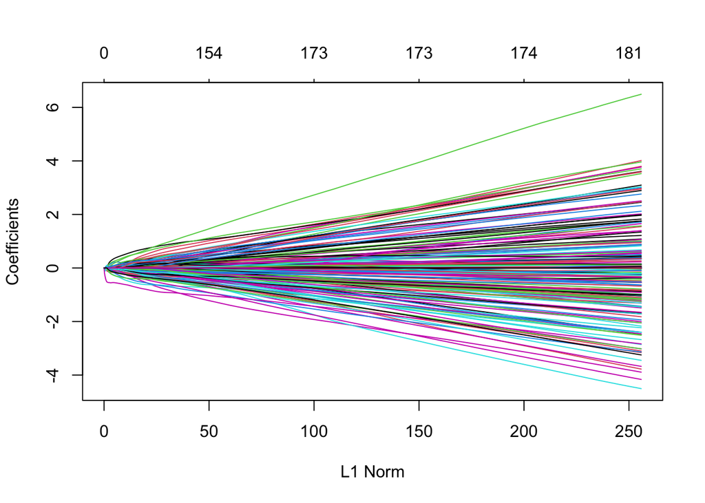

```r
lasso.fit <- glmnet(x,y,family="binomial",alpha=1)
plot(lasso.fit)
```

This plot represents the change in all coefficients when the L-1 norm is changed (or different $\lambda$ values). X-axis is the L-1 norm of coefficients, Y-axis is coefficient values of all variables. The numbers at the top of the figure are the number of variables with non-zero coefficients.

3.2. Perform 10-fold cross validation. To facilitate grading, set the seed to 777. Create a plot of the mean deviance versus log lambda from cross-validation. You may need to adjust the values of lambda so that the minimum is in the interior of the range of lambda.

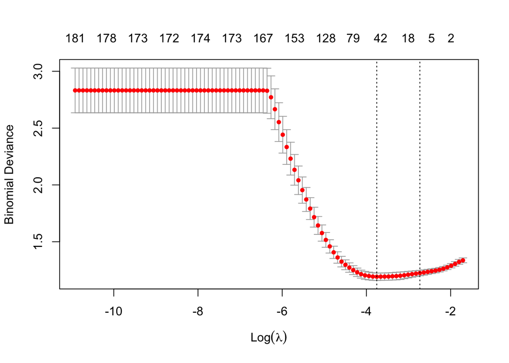

```r
set.seed(777)
cv.lasso.fit = cv.glmnet(x,y,family="binomial",alpha=1)
plot(cv.lasso.fit)
```

3.3. Create a plot of the coefficients estimated using lambda.min versus index number. Exclude the intercept, and color by the labels. Do you notice any patterns?

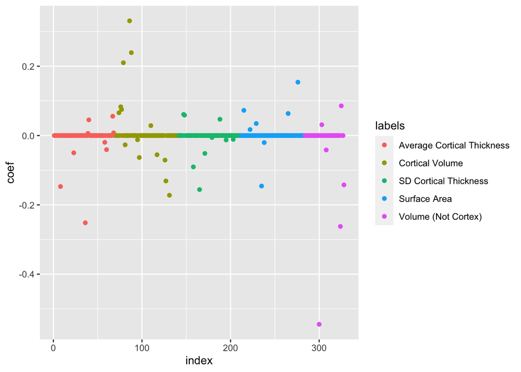

```r
tmp <- data.frame(coef=coef(cv.lasso.fit,s="lambda.min")[-1],labels=labels)
tmp$index <- 1:nrow(tmp)
ggplot(tmp,aes(x=index,y=coef))+geom_point(aes(color=labels))
```

The majority of the estimated coefficients were shrunk to 0 using lambda.min. Within each category of variables, several variables were selected with non-zero coefficients.

3.4. How many coefficients are not equal to 0?

```r
sum(coef(cv.lasso.fit,s="lambda.min")[-1]!=0)
```

```
## [1] 45
```

3.5. Which variable has the largest (in absolute value) coefficient at lambda.min? Transform the coefficient to the odds scale and interpret.

```r
abs <- abs(coef(cv.lasso.fit,s="lambda.min")[-1])
colnames(x)[which.max(abs)]
```

```
## [1] "Volume (WM Parcellation) of LeftHippocampus"
```

```r
est <- coef(cv.lasso.fit,s="lambda.min")[-1][which.max(abs)]
est
```

```
## [1] -0.5446404
```

```r
exp(est)
```

```
## [1] 0.5800504
```

```r
1 - exp(est)
```

```
## [1] 0.4199496
```

Holding all other features constant, a 1 standard deviation increase in scaled volume of this structure is associated with an approximately 42% decrease in the odds of being mild cognitive impairment.

3.6. Now set the seed to 123 and re-run the cross-validation. Plot the mean deviance versus log lambda. Did the plot change? Did lambda.min change?

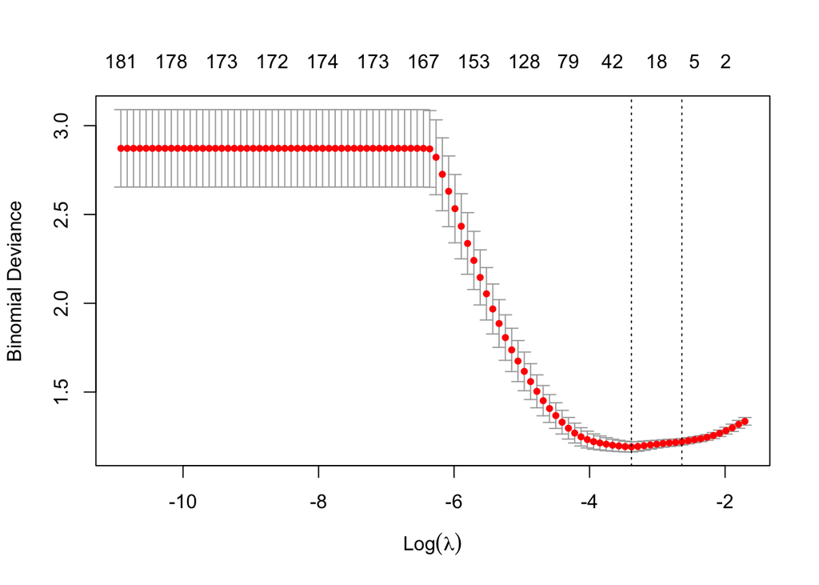

```r
set.seed(123)
cv.lasso.fit2 = cv.glmnet(x,y,family='binomial',alpha=1)
plot(cv.lasso.fit2)
```

```r
cv.lasso.fit$lambda.min
```

```
## [1] 0.02342279
```

```r
cv.lasso.fit2$lambda.min
```

```
## [1] 0.03398246
```

The plot maintains the same curve, but changes slightly. Lambda.min also changed slightly.

3.7. If you used ridge regression and cross-validation, how many variables would be selected at lambda.min? You don’t need to fit the model.

328 variables.

# 4 Elastic Net.

4.1. Fit the penalized glm with all predictors using the elastic net via $\texttt{glmnet}$. Choose the mixture of L1 and L2 penalties by setting $\alpha=0.5$. Create a plot using $\texttt{plot()}$.

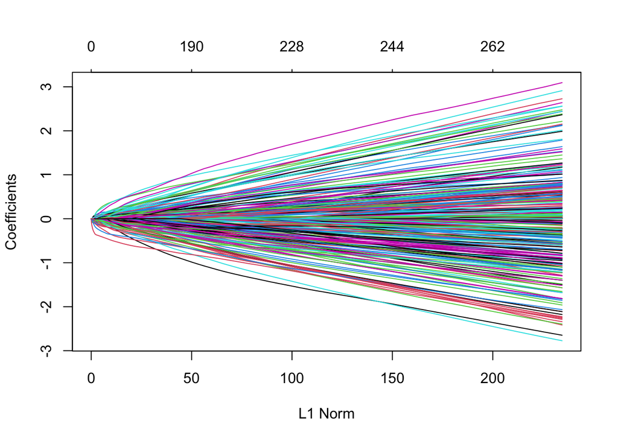

```r
elnet.fit = glmnet(x,y,family='binomial',alpha=0.5)
plot(elnet.fit)
```

4.2. Now, perform 10-fold cross validation. To facilitate grading, set the seed to 777. Create a plot of the mean deviance versus log lambda from cross-validation. If necessary, adjust the values of lambda to result in a minimum that is in the interior of the range of lambda.

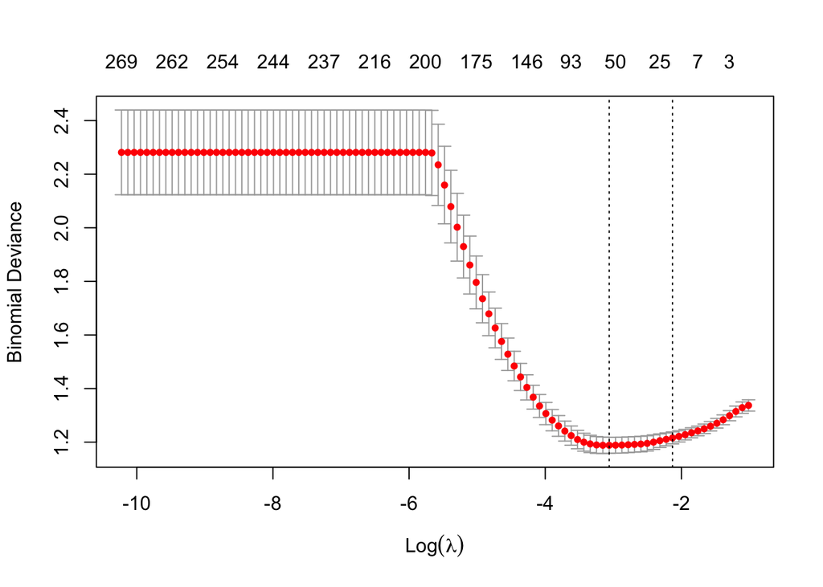

```r
set.seed(777)
cv.elnet.fit = cv.glmnet(x,y,family='binomial',alpha=0.5)
plot(cv.elnet.fit)
```

4.3. Create a plot of the coefficients estimated using lambda.min versus index number, coloring by the labels. Exclude the intercept. How does it compare to the lasso?

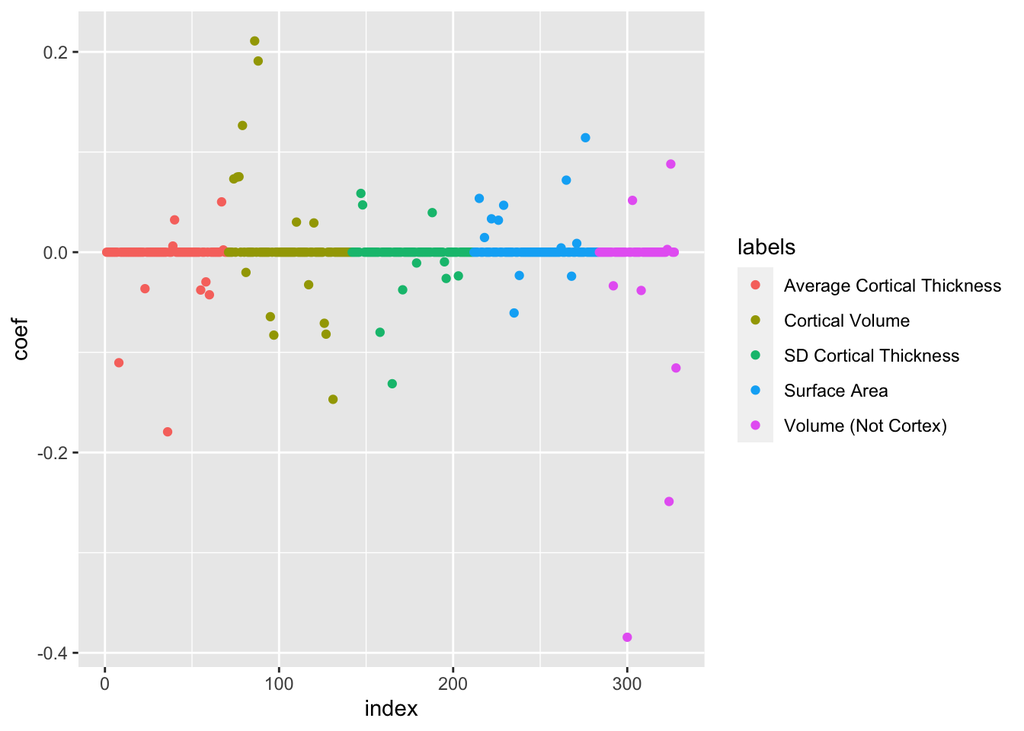

```r
tmp <- data.frame(coef=coef(cv.elnet.fit,s="lambda.min")[-1],labels=labels)
tmp$index <- 1:nrow(tmp)
ggplot(tmp,aes(x=index,y=coef))+geom_point(aes(color=labels))
```

The two plots are similar. Elastic Net with $\alpha=0.5$ selected slightly more variables with non-zero coefficients than Lasso. The magnitudes of the coefficients are smaller in Elastic Net than in Lasso.

4.4. How many coefficients are not equal to 0?

```r
sum(coef(cv.elnet.fit,s="lambda.min")[-1]!=0)
```

```
## [1] 55
```

4.5. Create a plot of the coefficients estimated using lambda.1se versus index number, coloring by the labels. Do you notice any patterns? How does the plot compare to using lambda.min?

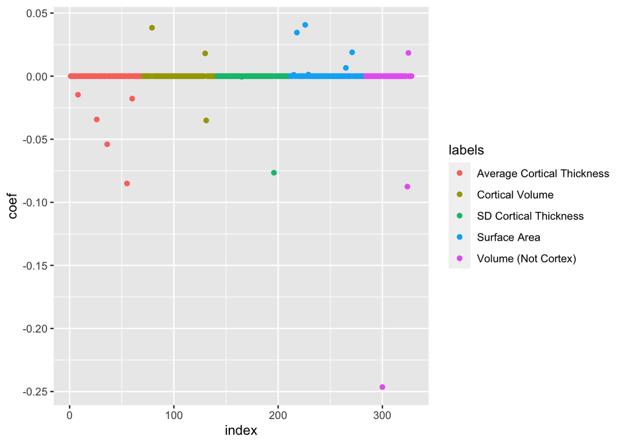

```r
tmp <- data.frame(coef=coef(cv.elnet.fit,s="lambda.1se")[-1],labels=labels)
tmp$index <- 1:nrow(tmp)
ggplot(tmp,aes(x=index,y=coef))+geom_point(aes(color=labels))
```

Here, there appears to be greater shrinkage. The number of coefficients shrunk to zero appears to have increased.

4.6. Which variable has the largest (in absolute value) coefficient at lambda.1se? Transform the coefficient to the odds scale and interpret.

```r
abscoef <- abs(coef(cv.elnet.fit,s="lambda.1se")[-1])
colnames(x)[which.max(abscoef)]
```

```
## [1] "Volume (WM Parcellation) of LeftHippocampus"
```

```r
est <- coef(cv.elnet.fit,s="lambda.1se")[-1][which.max(abscoef)]
est
```

```
## [1] -0.2464359
```

```r
1 - exp(est)
```

```
## [1] 0.2184186
```

Holding all other features constant, a 1 standard deviation increase in scaled volume of this structure is associated with an approximately 22% decrease in the odds of being mild cognitive impairment.

4.7. What is the advantage of elastic net over the lasso? What is the advantage of elastic net over ridge? Answer this in two sentences using the lecture notes.

Elastic net is less sensitive than lasso to correlation between covariates and tends to shrinks correlated covariates together. Elastic net tends to shrink some coefficients to exact zero and therefore provides better variable selection than ridge.

4.8 Now fit a glm using only the variables selected by the elastic net with lambda.1se. Print the output of summary.

```r
selected.data = data.frame(y, x[, which(abscoef!=0)], check.names = F)
glm.fit <- glm(y ~ ., family = 'binomial', data = selected.data)
summary(glm.fit)
```

```
##
## Call:
## glm(formula = y ~ ., family = "binomial", data = selected.data)
##
## Deviance Residuals:
##     Min       1Q   Median       3Q      Max
## -2.5068  -0.8597   0.4174   0.8284   2.0810
##
## Coefficients:
##                                                                    Estimate
## (Intercept)                                                         0.69479
## `Cortical Thickness Average of RightPosteriorCingulate`            -0.20261
## `Cortical Thickness Average of LeftEntorhinal`                      0.06161
## `Cortical Thickness Average of LeftMiddleTemporal`                 -0.11552
## `Cortical Thickness Average of LeftUnknown`                        -0.13544
## `Cortical Thickness Average of RightEntorhinal`                     0.12281
## `Volume (Cortical Parcellation) of Icv`                             0.16119
## `Volume (Cortical Parcellation) of RightCuneus`                     0.32040
## `Volume (Cortical Parcellation) of RightEntorhinal`                -0.41840
## `Cortical Thickness Standard Deviation of LeftCaudalMiddleFrontal` -0.29512
## `Cortical Thickness Standard Deviation of LeftUnknown`              0.09861
## `Surface Area of RightParsOrbitalis`                                0.22583
## `Surface Area of RightPostcentral`                                  0.13217
## `Surface Area of RightSuperiorTemporal`                             0.26396
## `Surface Area of RightTransverseTemporal`                           0.09040
## `Surface Area of LeftTemporalPole`                                  0.23127
## `Surface Area of RightCuneus`                                      -0.13982
## `Volume (WM Parcellation) of LeftHippocampus`                      -0.78554
## `Volume (WM Parcellation) of RightHippocampus`                     -0.16819
## `Volume (WM Parcellation) of RightInferiorLateralVentricle`         0.12007
##                                                                    Std. Error
## (Intercept)                                                           0.13924
## `Cortical Thickness Average of RightPosteriorCingulate`               0.16382
## `Cortical Thickness Average of LeftEntorhinal`                        0.23782
## `Cortical Thickness Average of LeftMiddleTemporal`                    0.19599
## `Cortical Thickness Average of LeftUnknown`                           0.27528
## `Cortical Thickness Average of RightEntorhinal`                       0.23741
## `Volume (Cortical Parcellation) of Icv`                               0.23784
## `Volume (Cortical Parcellation) of RightCuneus`                       0.29454
## `Volume (Cortical Parcellation) of RightEntorhinal`                   0.17804
```

[output cut: 48 more lines]

```
## `Surface Area of LeftTemporalPole`                                   0.1184
## `Surface Area of RightCuneus`                                        0.6555
## `Volume (WM Parcellation) of LeftHippocampus`                        0.0140 *
## `Volume (WM Parcellation) of RightHippocampus`                       0.5923
## `Volume (WM Parcellation) of RightInferiorLateralVentricle`          0.5608
## ---
## Signif. codes:  0 '***' 0.001 '**' 0.01 '*' 0.05 '.' 0.1 ' ' 1
##
## (Dispersion parameter for binomial family taken to be 1)
##
##     Null deviance: 466.75  on 349  degrees of freedom
## Residual deviance: 359.10  on 330  degrees of freedom
## AIC: 399.1
##
## Number of Fisher Scoring iterations: 5
```

4.9 Using the glm estimate, transform the coefficient corresponding to the variable in 4.6 to the odds scale and interpret.

```r
est <- unname(glm.fit$coefficients["`Volume (WM Parcellation) of LeftHippocampus`"])
est
```

```
## [1] -0.785541
```

```r
1-exp(est)
```

```
## [1] 0.544127
```

Holding all other features constant, a 1 standard deviation increase in scaled volume of this structure is associated with an approximately 54% decrease in the odds of being mild cognitive impairment.